# R筆記–(6)關聯式規則；決策樹(分析鐵達尼號資料)

skydome20

2016/04/27

[返回主目錄](https://rpubs.com/skydome20/Table)

#### Co-authors: [Jeff Hung](https://rpubs.com/jeff_datascience/DS_Notebook)

# 本篇目錄

1. 關聯式規則(Association Rules)
   - apriori()建立關聯規則
   - 冗規則判斷與去除
   - 視覺化
2. 決策樹(Decision Tree)
   - rpart()建立決策樹
   - 視覺化
   - 預測
3. 總結
4. Reference
5. R and packages version

# 1. 關聯式規則(Association Rules)

這裡拿網路上一個公開資料(鐵達尼號的乘客資料)來進行分析，[資料載點如下](http://www.rdatamining.com/data/titanic.raw.rdata?attredirects=0&d=1)。

下載之後，你會發現資料的型態並非熟悉的.csv。

因此我們要用**函式**把資料匯入到R裡面，使用的函式是`load()`：

```r
# 記得要給定資料所在的路徑(path)，例如：我把下載的資料放在C槽下：
load("titanic.raw.rdata")  #匯入.rdata檔
```

**(補充：如果我們要匯入.csv檔，除了之前教的方法以外，也可以用函式`read.csv()`)**

```r
data <- read.csv("C:/data.csv")
```

並且用`str()`看這筆資料的狀態

```r
str(titanic.raw)
```

```
## 'data.frame':    2201 obs. of  4 variables:
##  $ Class   : Factor w/ 4 levels "1st","2nd","3rd",..: 3 3 3 3 3 3 3 3 3 3 ...
##  $ Sex     : Factor w/ 2 levels "Female","Male": 2 2 2 2 2 2 2 2 2 2 ...
##  $ Age     : Factor w/ 2 levels "Adult","Child": 2 2 2 2 2 2 2 2 2 2 ...
##  $ Survived: Factor w/ 2 levels "No","Yes": 1 1 1 1 1 1 1 1 1 1 ...
```

可以發現資料裡面有四個欄位：

1. Class：乘客的艙位等級
2. Sex：乘客性別
3. Age ：乘客年齡
4. Survived：沉船之後，乘客是否存活？

關於鐵達尼號的故事，大家應該都耳熟能詳。而當我們說「女性比較容易存活」、以及「男性船員幾乎活不下來」，相信也沒人會反對吧？

畢竟電影就是這樣演的嘛！

可是，說歸說，如果要證明的話，該怎麼做呢？

啊啊啊！腦袋卡住了……

好啦，就不賣關子了。事實上這件事其實並不難。

其中一個方法，就是本篇即將用到的第一個方法：**關聯式法則(apriori)**！(對應的套件：`arules`)

## apriori()建立關聯規則

```r
require(arules) # apriori關聯式法則的套件
```

還記得apriori演算法是怎麼運作的嗎？我們需要設定：

- 支持度(min support)：「規則」在資料內具有普遍性，也就是這些 A 跟 B 同時出現的機率多少。
- 信賴度(min confidence)：「規則」要有一定的信心水準，也就是當購買 A 狀態下，也會購買 B 的條件機率。

(以上忘記的話，趕緊去讀熟XD)

而我們想要探討的規則，形式如下：「在A情況下，會存活與否」

換句話說，可以寫成**A => 存活與否**，所以把Survived這個變數放在`=>`的右手邊(right hand side)

```r
# apriori rules with rhs containing "Survived" only

rule <- apriori(titanic.raw,
                # min support & confidence, 最小規則長度(lhs+rhs)
                parameter=list(minlen=3, supp=0.1, conf=0.7),
                appearance = list(default="lhs",
                                  rhs=c("Survived=No", "Survived=Yes")
                                  # 右手邊顯示的特徵
                                  )
                )
```

要觀察rule需要使用`inspect()`的函式：

```r
inspect(rule)
```

```
##     lhs                                rhs            support   confidence
## [1] {Sex=Female,Age=Adult}          => {Survived=Yes} 0.1435711 0.7435294
## [2] {Class=3rd,Sex=Male}            => {Survived=No}  0.1917310 0.8274510
## [3] {Class=3rd,Age=Adult}           => {Survived=No}  0.2162653 0.7591707
## [4] {Class=Crew,Sex=Male}           => {Survived=No}  0.3044071 0.7772622
## [5] {Class=Crew,Age=Adult}          => {Survived=No}  0.3057701 0.7604520
## [6] {Sex=Male,Age=Adult}            => {Survived=No}  0.6038164 0.7972406
## [7] {Class=3rd,Sex=Male,Age=Adult}  => {Survived=No}  0.1758292 0.8376623
## [8] {Class=Crew,Sex=Male,Age=Adult} => {Survived=No}  0.3044071 0.7772622
##     lift     count
## [1] 2.301699  316
## [2] 1.222295  422
## [3] 1.121433  476
## [4] 1.148157  670
## [5] 1.123325  673
## [6] 1.177669 1329
## [7] 1.237379  387
## [8] 1.148157  670
```

這時候，看你是想根據 support 大小，或是 lift 大小排序 rules ：

```r
# 以下舉 lift 為例
sort.rule <- sort(rule, by="lift")
inspect(sort.rule)
```

```
##     lhs                                rhs            support   confidence
## [1] {Sex=Female,Age=Adult}          => {Survived=Yes} 0.1435711 0.7435294
## [2] {Class=3rd,Sex=Male,Age=Adult}  => {Survived=No}  0.1758292 0.8376623
## [3] {Class=3rd,Sex=Male}            => {Survived=No}  0.1917310 0.8274510
## [4] {Sex=Male,Age=Adult}            => {Survived=No}  0.6038164 0.7972406
## [5] {Class=Crew,Sex=Male}           => {Survived=No}  0.3044071 0.7772622
## [6] {Class=Crew,Sex=Male,Age=Adult} => {Survived=No}  0.3044071 0.7772622
## [7] {Class=Crew,Age=Adult}          => {Survived=No}  0.3057701 0.7604520
## [8] {Class=3rd,Age=Adult}           => {Survived=No}  0.2162653 0.7591707
##     lift     count
## [1] 2.301699  316
## [2] 1.237379  387
## [3] 1.222295  422
## [4] 1.177669 1329
## [5] 1.148157  670
## [6] 1.148157  670
## [7] 1.123325  673
## [8] 1.121433  476
```

看第一個關聯規則：「若身分是成人女性 => 則會存活」，lift=2.3 > 1，表示這個規則相當具有正相關；但其 support 卻沒有想像中的高，這也可以理解，因為當時那個年代，船上的女性人數應該遠低於男性人數，因此女性的樣本數較少，造成 support 較低也是合理的。

## 冗規則判斷與去除

然而，有發現到問題嗎？

第六個關聯規則(#編號8)「若身分是男性成人船員 => 不會存活」，對比於第五個關聯規則(#編號4)：「若身分是男性船員 => 不會存活」，其實看不到任何有用的資訊！

而且，第六個規則的lift <= 第五個規則的lift， 當發生這樣的情況時，我們就可以說：第六個關聯規則是**多餘的(redundant)**。

多餘的關聯法則，會造成分析上的雜訊，因此需要刪除它們，但該怎麼做呢？

首先，先看某項規則是否為其他規則的子集(subset)：(註，因套件版本的問題，函式回傳的矩陣有所改變，因此下面提供兩種不同的寫法，請依據自己的套件版本來撰寫)

```r
# 先根據 support 大小排序 rules
sort.rule <- sort(rule, by="support")

# 'arules' version = 1.4-2 , under R-3.2.5
subset.matrix <- is.subset(x=sort.rule, y=sort.rule)

# 'arules' version = 1.5-2 , under R-3.4.0
subset.matrix <- as.matrix(is.subset(x=sort.rule, y=sort.rule))
```

輸出的格式會像這樣：

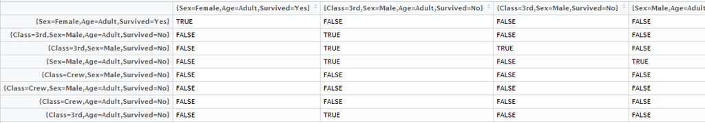

上面的結果要解釋很簡單：在X的項目，如果是Y項目的子集(subset)，就會回傳TRUE。  
(當你用RStudio打開**subset.matrix**這個變數時，會看見一個8x8的矩陣)

之後再進行以下步驟：

```r
# 把這個矩陣的下三角去除，只留上三角的資訊
subset.matrix[lower.tri(subset.matrix, diag=T)] <- NA

# 計算每個column中TRUE的個數，若有一個以上的TRUE，代表此column是多餘的
redundant <- colSums(subset.matrix, na.rm=T) >= 1

# 移除多餘的規則
sort.rule <- sort.rule[!redundant]

inspect(sort.rule)
```

```
##     lhs                       rhs            support   confidence lift
## [1] {Sex=Male,Age=Adult}   => {Survived=No}  0.6038164 0.7972406  1.177669
## [2] {Class=Crew,Age=Adult} => {Survived=No}  0.3057701 0.7604520  1.123325
## [3] {Class=Crew,Sex=Male}  => {Survived=No}  0.3044071 0.7772622  1.148157
## [4] {Class=3rd,Age=Adult}  => {Survived=No}  0.2162653 0.7591707  1.121433
## [5] {Class=3rd,Sex=Male}   => {Survived=No}  0.1917310 0.8274510  1.222295
## [6] {Sex=Female,Age=Adult} => {Survived=Yes} 0.1435711 0.7435294  2.301699
##     count
## [1] 1329
## [2]  673
## [3]  670
## [4]  476
## [5]  422
## [6]  316
```

經過以上步驟後，多餘的規則消失了！

## 視覺化

在R裡面，關聯式規則還提供一個視覺化的套件`arulesViz`，可以觀察每條規則的三項指標分布情況：

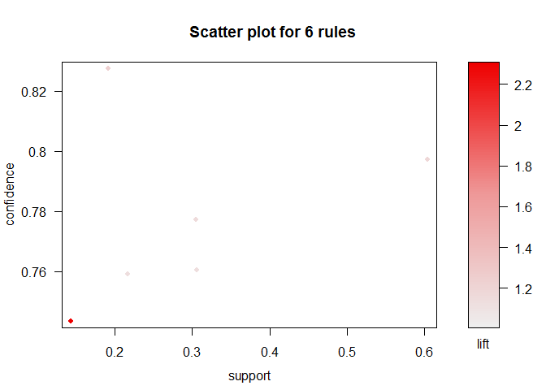

```r
require(arulesViz)
plot(sort.rule)
```

而且也可以將規則視覺化，知道當初災難發生以後，在什麼樣的條件下比較容易存活/死亡：

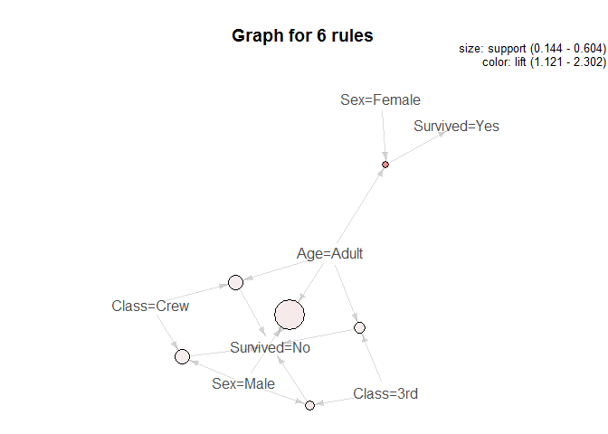

```r
plot(sort.rule, method="graph")
```

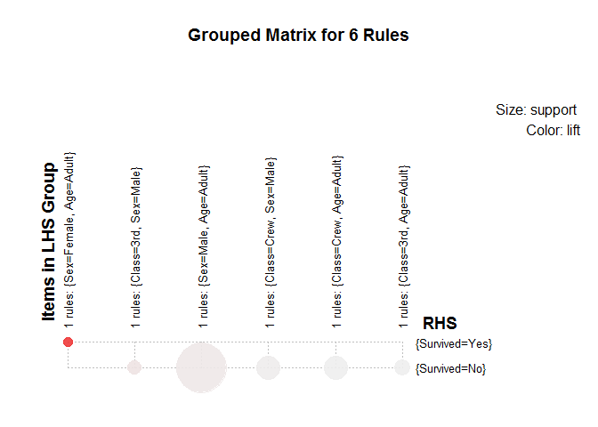

```r
plot(sort.rule, method="grouped")
```

現在對照一開始的假設：**「女性比較容易存活」、「男性船員幾乎死光光」、「3rd 客艙的成人幾乎無法存活」**…嗯嗯嗯(點頭)！

不同的是，現在你的手上已經有證據了！因此下次跟別人一起看鐵達尼號時，就大方地拿來說嘴吧！

# 2. 決策樹(Decision Tree)

無論在分類或預測上，決策樹的演算法都有很好的效果。

但它最強大的地方，莫過於樹狀分支的結構：可以明顯呈現分類的規則！與一些機器學習的方法(NN, SVM…)相比，相當容易進行解釋，以及分析規則之間的關係。

## rpart()建立決策樹

這裡就簡單用CART決策樹來練習，對應的套件是`rpart`，一樣使用剛才鐵達尼號的資料：

```r
require(rpart)

# 先把資料區分成 train=0.8, test=0.2
set.seed(22)
train.index <- sample(x=1:nrow(titanic.raw), size=ceiling(0.8*nrow(titanic.raw) ))
train <- titanic.raw[train.index, ]
test <- titanic.raw[-train.index, ]

# CART的模型：把存活與否的變數(Survived)當作Y，剩下的變數當作X
cart.model<- rpart(Survived ~. ,
                    data=train)
```

## 視覺化

要畫出決策樹(視覺化)，雖然用平常的`plot()`就可以達成

但rpart有專屬的繪圖套件`rpart.plot`，函式是`prp()`

說真的，用`prp()`畫出來的決策樹，比較好看一些：

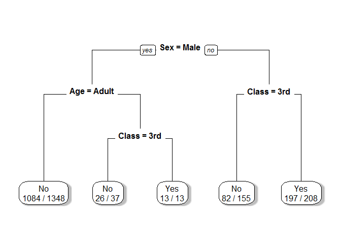

```r
require(rpart.plot)
prp(cart.model,         # 模型
    faclen=0,           # 呈現的變數不要縮寫
    fallen.leaves=TRUE, # 讓樹枝以垂直方式呈現
    shadow.col="gray",  # 最下面的節點塗上陰影
    # number of correct classifications / number of observations in that node
    extra=2)
```

(最下面節點的數字，代表：**number of correct classifications / number of observations in that node**)

根據以上決策樹，可以發現**是男生或女生**其實很重要(因為是第一個分支規則)，其次是在船上的艙位等級。

因此，我們可以這樣解釋：

```
即使是女性，可是擁有的艙位若是最低下的(3rd)，則大概有一半的死亡機率(82/155=53%)；
但當妳的艙位高人一等時，則有相當高的存活機率(197/208=95%)。
```

又或者是：

```
當你是男性成人時，大概有八成機率會死(1084/1348=80%)，合理推測剩下兩成是貴族(?)
```

以及

```
若是男性小孩，就和艙位等級有關：高級艙位的小孩全都獲救(13/13)，可是低艙位的小孩有七成機率(26/37)會死。
```

**(OS：男生好可憐QHQ 這個社會好現實QHQ)**

## 預測

有決策樹之後，就要進行預測啦！

還記得在線性迴歸使用過的`predict()`嗎？這時就會派上用場囉(在這裡，會同時計算預測準確率)：

```r
pred <- predict(cart.model, newdata=test, type="class")

# 用table看預測的情況
table(real=test$Survived, predict=pred)
```

```
##      predict
## real   No Yes
##   No  278   9
##   Yes  93  60
```

```r
# 計算預測準確率 = 對角線的數量/總數量
confus.matrix <- table(real=test$Survived, predict=pred)
sum(diag(confus.matrix))/sum(confus.matrix) # 對角線的數量/總數量
```

```
## [1] 0.7681818
```

# 3. 總結

和一些機器學習方法只會專注在「預測準確率」的概念不太一樣，，關聯式法則和決策樹在「解釋」上具有十分強大的優勢。

的確，在現實中，有時候確實只要「高的預測準確率」的模型，就可以達成許多目標。

可是也千萬別忘記了，我們正在進行的是「資料分析」，也就是去「解釋」資料中的故事。

事實上，有時候這個步驟反而會比「準確率」還重要。這一點，稍微思考一下就能理解了：唯有去探討資料的故事，才有機會發現到**有趣的跡象、失敗的原因、違背直覺的現象……**等等。

而且，這樣才有一種……真正在進行「資料分析」的感覺，不是嗎？

It’s still a long way to go~

# 4. Reference

[http://www.rdatamining.com/examples/association-rules](http://www.rdatamining.com/examples/association-rules  
)

[https://www.kaggle.com/c/titanic](https://www.kaggle.com/c/titanic  
)

# 5. R and packages version

這是本篇筆記使用R跟套件版本：

```r
pkgs = c("arules", "arulesViz", "rpart.plot", "rpart")
r_version = paste("R", getRversion())
pkg_version = c()
for (package_name in pkgs) {
    pkg_version = c(pkg_version,
                    paste(package_name,packageVersion(package_name)))
}
c(r_version, pkg_version)
```

```
## [1] "R 3.4.3"          "arules 1.5.5"     "arulesViz 1.3.0"
## [4] "rpart.plot 2.1.2" "rpart 4.1.13"
```